# The Politics of Corruption

Lecture 10: China and Hong Kong — Growth, Clean Government, and Anti-Corruption Campaigns

Bogdan G. Popescu

bgpopescu@tec.mx

Tecnológico de Monterrey

## What to make of Diego’s deal

Four scenes, and not one of them has a man with a briefcase of cash.

- Only the city could sell that land, so access to it was worth something from the start
- The price was a share of the profits for the official’s **brother**, not an envelope
- The towers went up and the jobs were real
- The better builders never got to bid, and the city sold low

Nothing was stolen outright, and the city grew. That is the hard part.

**Today:** can corruption and growth go together, and who carries the cost? Then: if a country wants to clean this up, what actually works?

# Part I — The puzzle: boom and bribes

## The boom is not in doubt

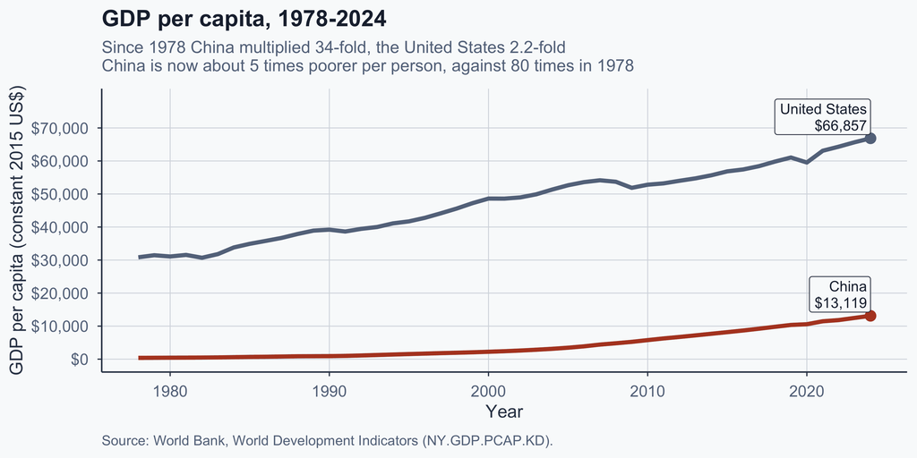

## Two ways to compare economies

To compare two countries’ GDP you have to put them in the same currency — and there are two ways.

- **Market exchange rates.** China’s GDP is converted into dollars at the day’s rate: the price at which currencies are actually bought and sold.
- **Purchasing power parity.** Adjusts for what things cost in each country. A meal or a haircut costs less in China, so the same money buys more — and its economy looks bigger.

Neither is wrong: the first measures what China’s output is worth on world markets; the second, how far it goes for the people who live there.

## Catching up, depending on how you measure

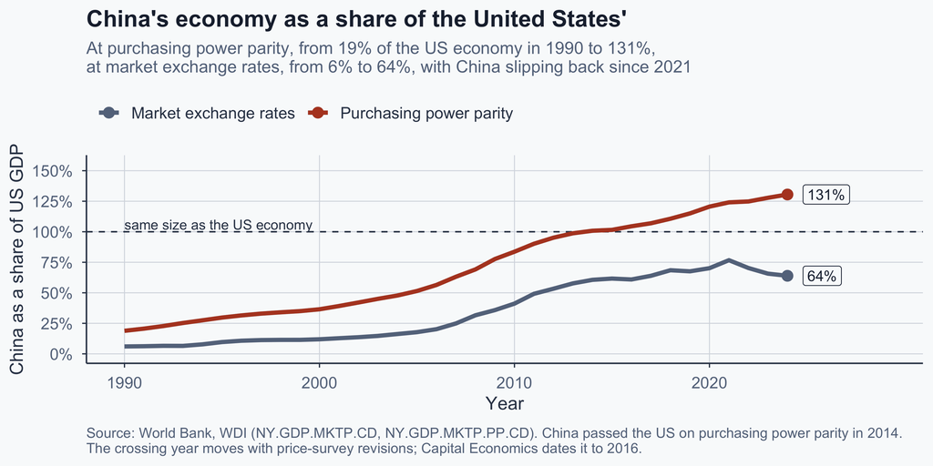

Per person China is still about five times poorer. In total size it has either overtaken the United States or is two-thirds of it. Nothing about China changes between those two sentences — only the exchange rate used to compare.

## What corruption is supposed to do to growth

China did all of that during decades when corruption was widespread. On the standard account, it should not have been able to.

```
%%{init: {"fontSize": 22, "htmlLabels": false, "flowchart": {"useMaxWidth": true, "nodeSpacing": 45, "rankSpacing": 55, "htmlLabels": false, "padding": 14, "curve": "basis"}, "themeVariables": {"fontSize": "22px", "fontFamily": "DM Sans, Segoe UI, sans-serif", "primaryColor": "#eef2f5", "primaryText…
flowchart LR
  A["Officials can<br/>demand bribes"] --> B["Investing costs<br/>more and is<br/>less certain"]
  A --> D["Public money<br/>is diverted"]
  B --> C["Firms invest less<br/>and stay small"]
  D --> E["Worse roads,<br/>schools<br/>and courts"]
  C --> F["Slower<br/>growth"]
  E --> F
  classDef bad fill:#f6e7df,stroke:#b44527,stroke-width:2px,color:#1e293b;
  class F bad;
```

Every arrow runs the same way: down. If this is the whole story, Diego’s city should have stalled — and it did not.

Author’s illustration of the standard argument. No units; conceptual only.

## China did the opposite

- From 1978 to 2010 the economy grew roughly 9% a year
- Corruption did not fall as markets deepened — it changed shape
- Wedeman calls this China’s **double paradox**: growth and graft rose together

So either the diagram on the last slide is wrong, or it is missing something.

Source: Wedeman (2012), *Double Paradox*, ch. 1.

## The simple cross-country relationship is weak

And China is not a lone exception.

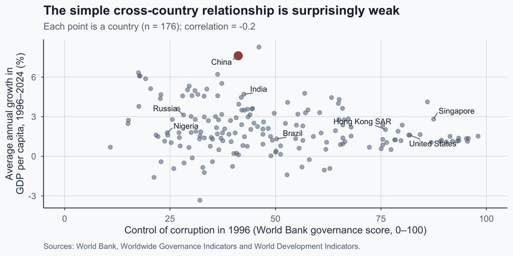

Descriptive only. No controls for starting income, region or measurement error, and the base year is arbitrary. This motivates the puzzle; it does not test the corruption–growth hypothesis.

## So what?

> Counting corruption tells us how much. It does not tell us **what kind**.
- The standard argument predicts slower growth; China grew fastest while graft rose
- Across countries, the simple relationship is too weak to guide us either way
- Both point the same way: *how much* corruption is the wrong question
- Hong Kong ran the opposite experiment in the same region

# Part II — Unbundling corruption (Ang)

## Ang’s four types of corruption

**Question 1.** Who is involved — a clerk, or a powerful politician?

**Question 2.** What is the act — *taking* (one side loses), or *trading* (both expect to gain)?

Ang’s typology unbundles corruption by actor and by act.

| Type | Who | The act | Likely effect on growth | Ang’s metaphor |
| --- | --- | --- | --- | --- |
| **Petty theft** | Non-elites | Steals or extorts | Damaging | Toxic drug |
| **Grand theft** | Elites | Embezzles large sums | Highly damaging | Toxic drug |
| **Speed money** | Non-elites | Trades: pays to hurry | A tax on business | Painkiller |
| **Access money** | Elites | Trades: buys privilege | Can accompany investment | Steroid |

Source: Ang (2020), ch. 1. Her claim is that the four types have different consequences — not that corruption causes growth.

## Session 6: which way does the arrow point?

Wallis asked one question about any corrupt exchange.

```
%%{init: {"fontSize": 22, "htmlLabels": false, "flowchart": {"useMaxWidth": true, "nodeSpacing": 90, "rankSpacing": 240, "htmlLabels": false, "padding": 18, "curve": "basis"}, "themeVariables": {"fontSize": "22px", "fontFamily": "DM Sans, Segoe UI, sans-serif", "primaryColor": "#eef2f5", "primaryTex…
flowchart LR
  A["PUBLIC OFFICE<br/>the power to decide"]
  B["ECONOMIC BENEFITS<br/>money, jobs, contracts"]
  A -- "VENAL<br/>office used for private gain" --> B
  B -- "SYSTEMATIC<br/>privileges used to sustain power" --> A
  classDef box fill:#eef2f5,stroke:#334155,stroke-width:2px,color:#1e293b;
  class A,B box;
```

**Systematic** is Wallis’s own term, and it does **not** mean widespread. It describes corruption that helps reproduce political power.

Source: Wallis (2006), p. 25, in Glaeser & Goldin, eds.

## Ang and Wallis on the same desk

The two frameworks ask different questions; the table below is only a rough alignment.

| Ang’s type | Which way the arrow points | What changes hands |
| --- | --- | --- |
| **Petty theft** | Venal | Small sums, taken or extorted |
| **Grand theft** | Venal | Large sums, embezzled |
| **Speed money** | Venal | A payment to be served sooner |
| **Access money** | Venal, sometimes **systematic** | A privilege, bought with a share of the profits |

Access money always pays the official. It is **systematic** only where the privileges are handed out to keep a political coalition in power.

Ang (2020), ch. 1; Wallis (2006), p. 25, in Glaeser & Goldin, eds. The mapping is the author’s.

## Why access money can ride alongside growth

**The same four scenes, as a diagram.** Where exactly was the corruption? Not in the building going up — in *who was allowed to build, and what the official got for allowing it*.

```
%%{init: {"fontSize": 22, "htmlLabels": false, "flowchart": {"useMaxWidth": true, "nodeSpacing": 45, "rankSpacing": 50, "htmlLabels": false, "padding": 14, "curve": "basis"}, "themeVariables": {"fontSize": "22px", "fontFamily": "DM Sans, Segoe UI, sans-serif", "primaryColor": "#e7efec", "primaryText…
flowchart LR
  A["Scene 1<br/>only the state<br/>sells the land"] --> B["Scene 2<br/>cheap land for<br/>a share of the profits"]
  B --> C["Scene 3<br/>the towers go up<br/>the jobs are real"]
  C --> D["Scene 4<br/>no rivals bid<br/>the city is paid less"]
  classDef deal fill:#f6e7df,stroke:#b44527,stroke-width:3px,color:#1e293b;
  classDef cost fill:#f6e7df,stroke:#b44527,stroke-width:2px,color:#1e293b;
  class B deal;
  class D cost;
```

**Why doesn’t the official just take the money and run?**

- Scene 2 promised him a **share of the profits**, not an envelope
- No towers, no profits, no share
- His career pointed the same way: officials were judged on growth
- Plain theft: the money leaves, nothing is built
- Access money: he is paid only if **Scene 3** happens
- So the bribe and the building rise together

Author’s illustration of a mechanism Ang (2020) proposes, not an estimated causal effect.

## What access money costs

**Scene 3, ten years on.** The towers are still standing. So is the debt that built them.

**Four costs follow from the deal itself:**

- Diego got the land through a connection, not because he builds well
- Across an economy, that means a lot of second-best firms doing the work
- The city was paid less than the land was worth, and that is public money
- What gets built depends on who knows whom rather than on what is needed

**And where this becomes the normal way of doing business, risks build up** — these are tendencies Ang warns about, not things one deal guarantees:

- Land and local government debt inflate together
- Towers go up that nobody moves into
- The insiders end up owning the new city
- Officials rise and fall with their patrons, so politics itself turns risky

Both things are true at the same time: the towers are real, and so is the bill.

Source: Ang (2020), ch. 1.

## If it is legal, is it corruption?

[figure not shown]

- Ang: China today rhymes with America’s Gilded Age
- The same years we studied in **Session 6** — Tweed’s New York, and this Senate
- Lobbying, donations and the revolving door buy access too
- In rich democracies most of that is perfectly legal
- Legal influence and a brown envelope are not the same thing

Joseph Keppler, *The Bosses of the Senate*, *Puck*, 23 January 1889. U.S. Senate Collection; public domain.

## Exercise 1 — Sort the bribe

**In pairs.** Put each case in one of Ang’s four boxes, then answer the question below.

1. A customs officer keeps part of the duties she collects.
2. A restaurant pays a clerk so its licence arrives this week, not in three months.
3. A minister moves public pension money into a private account.
4. A developer funds a mayor’s flagship project; the city then rezones its land.
5. **Session 6’s ward office.** A party volunteer works three months of evenings and is given a clerk’s job at the water department.

**Question.** You are the mayor. You can stop exactly one of these five tomorrow. Which one, and why?

## Ang’s boxes

Two questions — who is involved, and which act — give four boxes.

|  | **Taking** — one side loses | **Trading** — both expect to gain |
| --- | --- | --- |
| **Non-elites** | Petty theft | Speed money |
| **Elites** | Grand theft | Access money |

Source: Ang (2020), ch. 1.

## Exercise 1 — where the cases go

1. Customs officer keeps part of the duties she collects — **petty theft**
2. Restaurant pays a clerk so the licence arrives this week — **speed money**
3. Minister moves pension money into a private account — **grand theft**
4. Developer funds the mayor’s project; the city then rezones its land — **access money**

**Case 5 does not fit.** The volunteer trades evenings of party work for a clerk’s job — an exchange, and no elite is involved. But nothing is bought with money, and no rule is clearly broken. Most people would call that patronage.

Source: Ang (2020), ch. 1.

# Part III — Corruption by design (Manion)

## Hong Kong is not mainland China

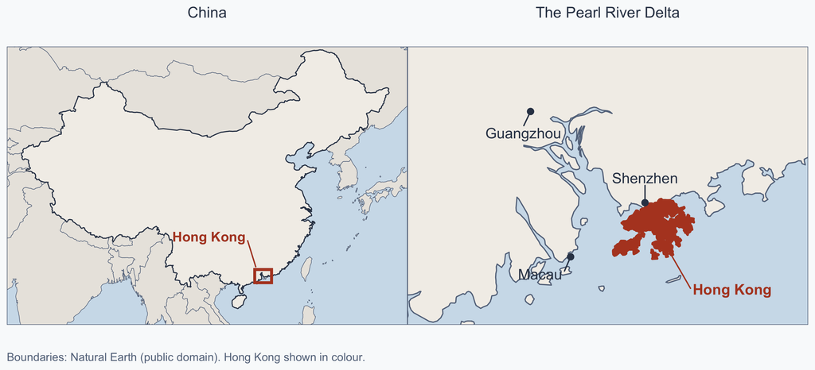

## Two histories, one coastline

|  | **Hong Kong** | **Mainland China** |
| --- | --- | --- |
| 1842 | Ceded to Britain after the First Opium War | Qing empire |
| 1949 | Still a British colony | People’s Republic founded |
| **1974** | **The Independent Commission Against Corruption (ICAC) is created, under British rule** |  |
| 1978 |  | Reform and opening begins |
| 1997 | Returned to China | “One country, two systems” |

The reform we are about to study was carried out by a colonial government, twenty-three years before the handover. “The same country” is the wrong way to think about this comparison.

Founding date: ICAC, *History of the ICAC*.

## Hong Kong before the ICAC

- Ambulance crews asked for “tea money” before picking up a sick person
- In hospital, a tip bought you a bedpan or a glass of water
- Firemen were paid twice: once to turn the hose on, once to turn it off
- None of this was freelance. The police ran it as a business — *syndicated* corruption: set prices, collected on a schedule, shared upwards through the ranks
- In June 1973 a senior British officer in the Hong Kong police flew home
- He left days before he was due to be questioned about more than HK$4 million he could not explain
- The force’s own anti-corruption unit had been investigating him for two years, and had got nowhere
- People marched, and a public inquiry followed
- In February 1974 the government created an agency outside the police

The officer was Peter Godber; he was extradited in 1975 and jailed. Sources: Manion (2004), ch. 2; ICAC, official history of the commission.

## An agency placed outside the police

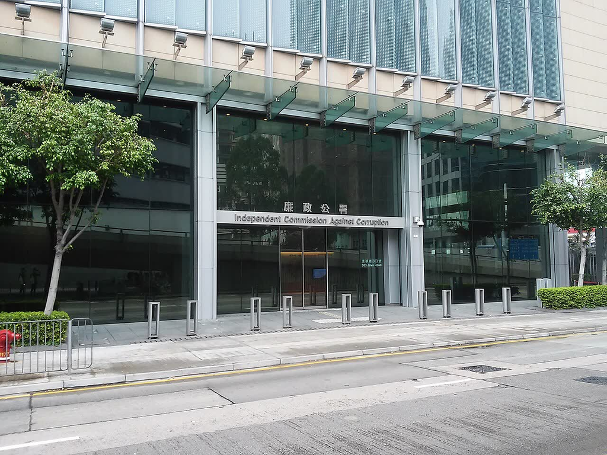

ICAC headquarters, North Point, Hong Kong. Photo: Citobun, CC BY-SA 4.0, via Wikimedia Commons. The Commissioner reports to the Chief Executive alone, and to the Governor before 1997 — not to the police, not to a ministry.

## Manion’s key idea: corruption is an equilibrium

```
%%{init: {"fontSize": 22, "htmlLabels": false, "flowchart": {"useMaxWidth": true, "nodeSpacing": 45, "rankSpacing": 55, "htmlLabels": false, "padding": 14, "curve": "basis"}, "themeVariables": {"fontSize": "22px", "fontFamily": "DM Sans, Segoe UI, sans-serif", "primaryColor": "#eef2f5", "primaryText…
flowchart LR
  A["Everyone expects<br/>officials to<br/>take bribes"] --> B["For a citizen,<br/>paying is the<br/>sensible choice"]
  A --> C["For an official,<br/>refusing costs<br/>money and trust"]
  B --> D["Almost everyone<br/>takes part"]
  C --> D
  D -- "a few arrests<br/>change nothing" --> A
  classDef start fill:#f6e7df,stroke:#b44527,stroke-width:2px,color:#1e293b;
  class A start;
  linkStyle 4 stroke:#b44527,stroke-width:3px;
```

Author’s illustration of Manion (2004). Beliefs about how common corruption is are what hold the loop together.

## The ICAC attacks the loop at three points

```
%%{init: {"fontSize": 22, "htmlLabels": false, "flowchart": {"useMaxWidth": true, "nodeSpacing": 40, "rankSpacing": 55, "htmlLabels": false, "padding": 14, "curve": "basis"}, "themeVariables": {"fontSize": "22px", "fontFamily": "DM Sans, Segoe UI, sans-serif", "primaryColor": "#e7efec", "primaryText…
flowchart LR
  I["ICAC<br/>1974"] --> O["Deterrence:<br/>investigate<br/>and prosecute"]
  I --> P["Prevention:<br/>redesign<br/>procedures"]
  I --> C["Education:<br/>persuade and<br/>take reports"]
  O --> R1["Raises the risk<br/>of taking"]
  P --> R2["Removes the<br/>opportunity"]
  C --> R3["Changes what<br/>people expect"]
  R1 --> N["Clean becomes<br/>the new normal"]
  R2 --> N
  R3 --> N
  classDef goal fill:#e7efec,stroke:#4a7c6f,stroke-width:3px,color:#1e293b;
  class N goal;
```

The middle prong, redesigning procedures, is the American move — one of three, never the main one.

Author’s illustration. Manion (2004), ch. 2: reform needs all three prongs together.

## ▶ Hong Kong — inside the ICAC, forty years on

[video not shown]

1. The ICAC rests on deterrence, prevention and education. The first two are obvious. Why education?  
2. In 1973 taking a bribe was safe; today the ICAC sells mugs joking about it. Why can it sell that joke?  
3. China’s state broadcaster made this in 2014, mid-campaign. Why then, and what would convince you?

CCTV News (now CGTN) — ICAC open day, 40th anniversary, Hong Kong, February 2014. Plays 0:00-2:52.

## ▶ Hong Kong — worked

1. **Why education?**
   - The loop holds because everyone expects everyone else to pay
   - Arrests shift that expectation only if people hear about them
   - Education is how a prosecution becomes an expectation
   - The three prongs work as one
2. **Why the joke can be sold now**
   - Nobody doubts the threat behind it any more
   - Being summoned has to be real and routine before it can be funny
   - The open day is not time off from the work — it *is* the education prong
3. **Reading the source**
   - The ranking is a *perceptions* index, with all of Part I’s problems
   - No counterfactual: what else changed in Hong Kong after 1974?
   - A mainland broadcaster in 2014 had its own reason to tell this story — hold that against Part IV

The history segment of this report (2:52-4:36) covers Godber and the 1960s salary problem.

## Making the new expectation credible

- **Independence.** The Commissioner answered to the Governor directly, not to the police
- **Permanence.** A standing agency with its own staff and budget
- **Visibility.** Senior officers prosecuted, publicly and repeatedly
- **A line under the past.** Police protest in October 1977
- Partial amnesty: offences committed before 1 January 1977 not pursued
- Those already under investigation, wanted, or abroad were excluded

Sources: Manion (2004), ch. 2; ICAC official history. The amnesty closed the past once — not repeatedly.

## Two routes to clean government

Session 6 ended on a sentence worth repeating: *the United States did not get cleaner because better people arrived — it got cleaner because there was **less to sell**.*

|  | **United States (Session 6)** | **Hong Kong (from 1974)** |
| --- | --- | --- |
| The problem | **Systematic**: privilege bought political power | **Venal**: office sold for cash, at set prices |
| The fix | Remove what politicians had to sell | Make punishment and refusal believable |
| In practice | Anyone could incorporate, without a political favour | One agency, outside the police |
| What it changed | The **opportunity** | The **expectation** |
| How long | About fifty years, never complete | Visible within a decade |

Hong Kong could not take the discretion away — you cannot abolish the police. So it worked on the expectation instead. **If you cannot remove the temptation, can you still change what people expect?**

Sources: Manion (2004), ch. 6; Wallis (2006), p. 50, in Glaeser & Goldin, eds., *Corruption and Reform*.

## Fifty years later, the gap is still visible

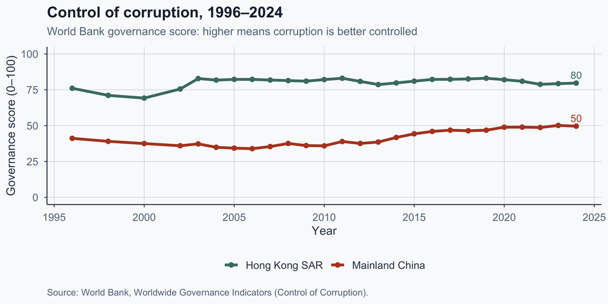

## But was it really the ICAC?

- The ICAC arrived in the middle of a much wider reform drive
- Hong Kong was small, rich and urban, not a continent
- Rising incomes made a civil-service job more costly to lose
- Courts and newspapers operated with real independence
- Manion shows the design was coherent; she cannot randomise it
- Read Hong Kong as a strong case, not a controlled experiment

Sources: Manion (2004), ch. 2; ICAC official history. These rival explanations are not tested here — that is the point.

## Exercise 2 — Would an ICAC work here?

**In pairs.**

Your country announces a new anticorruption commission tomorrow.

1. Name **one** design feature from Hong Kong you would copy, and say what it changes.
2. Name **one** reason it might fail where you live.

## So what?

> Manion’s answer for Hong Kong: it did not punish *harder*. It made punishment **credible**, and designed around it.

That is her argument, and the evidence is a well-documented case rather than an experiment. What it establishes is a **mechanism**: expectations can be shifted deliberately, and kept credible.

Mainland China also punishes corruption — heavily, and very publicly.

# Part IV — Campaigns and selectivity

## Two designs, side by side

Two institutional designs for fighting corruption.

| Design feature | Hong Kong ICAC (since 1974) | Mainland China (CCDI) |
| --- | --- | --- |
| Who investigates | Standing agency outside the police | Party’s own discipline body |
| Answers to | Governor, later Chief Executive | Party leadership |
| Who can be targeted | Public **and** private sector | Party members and public employees |
| Rhythm of enforcement | Continuous, routine | Waves and campaigns |
| Main lever | Everyday expectations | Discipline and loyalty |

Sources: Manion (2004), chs. 5–6; CCDI. Since 2018 a National Supervisory Commission extends the mainland’s reach to all public employees. **Caution:** these bodies sit inside very different political systems. This is a structured comparison, not a controlled experiment.

## Xi’s campaign: real, and very large

- Launched after the 18th Party Congress, November 2012
- Slogan: “tigers and flies” — senior leaders and local officials alike
- Zhou Yongkang, a former Politburo Standing Committee member, jailed for life
- CCDI: 4.39 million cases investigated, 4.7 million people punished
- That count runs from November 2012 to April 2022
- Nobody disputes the scale. The question is what it changed.

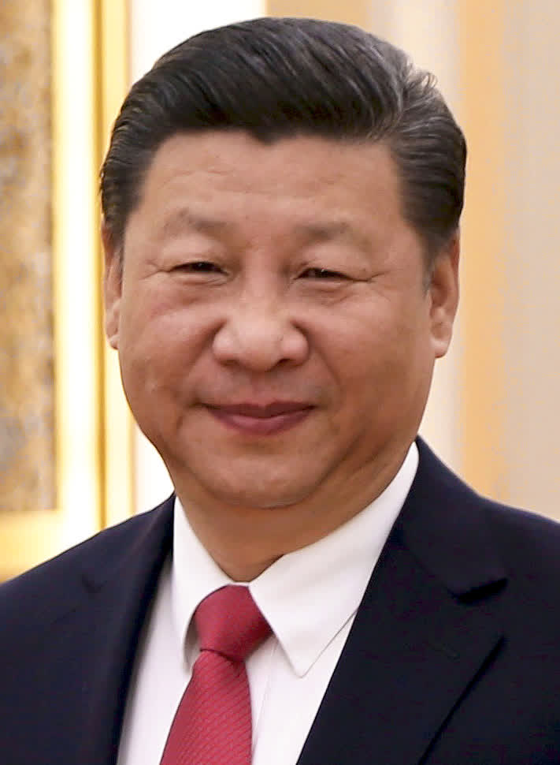

Xi Jinping, March 2017. U.S. Department of State; public domain.

Sources: CCDI press conference, June 2022 (as reported); court judgment in the Zhou Yongkang case, 11 June 2015.

## What a political connection was worth

**Diego’s deal, many times over.** Nobody can observe a secret profit share. But the state records every land sale, and Chen and Kung can tell which buyers were linked to the families of Politburo members — “princelings”. The favouritism turns up in the price, with nobody having to confess.

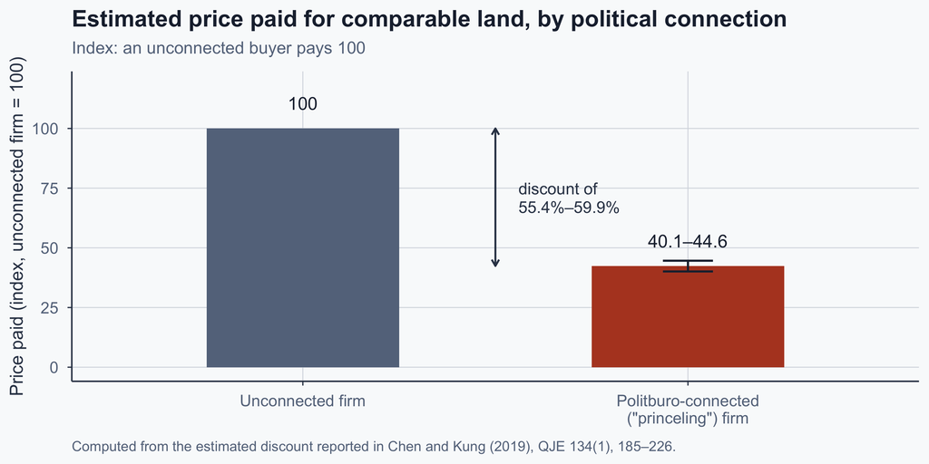

The developer at the door said *we might have offered the city more*. Connected firms paid far less for comparable land — evidence that fits his complaint, not a measurement of the bid he never made.

Source: Chen and Kung (2019), *Quarterly Journal of Economics*; over one million transactions, 2004–2016. Prices are recorded by the state, not self-reported in a survey.

## Why would an official give that discount?

**The buyer is not a stranger.** A “princeling” firm is owned by the family of a Politburo member — a son, a son-in-law.

- Nobody owns urban land in China — the **state** does, and has since 1982
- What is sold is a **use right** for 40 to 70 years, granted by the local government
- Say a parcel is worth **$100 million**; the princeling firm pays about **$42 million**
- Its owners are instantly **$58 million** richer
- Those owners are a national leader’s children
- That leader sits where promotions to national office are decided

**So the secretary pays a bribe to someone who can promote him — in land, to the man’s children, rather than in cash to the man.**

And it is deniable. A suitcase of cash is a crime; a land sale is a government decision that looks like policy. Nobody has to confess — the favour shows up in the price.

Illustrative figures, using the midpoint of the discount estimated by Chen and Kung (2019). Urban land is state-owned under the 1982 Constitution; use-right terms come from the 1990 Interim Regulations.

## Enforcement that is real, and also selective

**Did the campaign change anything?** Chen and Kung watch the same land prices before and after 2012.

- A province was “reached” when a central inspection team arrived, or when Xi appointed its new party secretary
- In those provinces the princeling discount shrank by about a third to two-fifths
- Princelings still paid less than everyone else, but much closer to the ordinary price — so the enforcement was real
- Before 2012, handing out those discounts was good for your career: the party secretaries who granted them were 23.4% more likely to reach national office
- After 2012 that route closed

Real, then — but aimed. The centre chose which provinces to inspect. Careful: that shows enforcement targeted at **places**, not proof that it spared the leadership’s own allies.

Source: Chen and Kung (2019), *Quarterly Journal of Economics*, 134(1), 185–226. Corruption, measured by that discount, fell by 31.5%–42.6% in the provinces the campaign reached.

## So what? Five things to take away

- Ask what kind of corruption a country has, not only how much
- Access money can live alongside growth; theft and extortion cannot
- The bill still arrives: the best builder loses, and the city is underpaid
- Corruption lasts because people expect it, and in 1973 nobody could refuse alone
- Clean government came from changing structure, not from trying harder

**Take-away:** corruption is an equilibrium. You break it by changing **what is for sale** (America) or **what people expect** (Hong Kong). A campaign raises the penalty without doing either — real while it runs.

And be careful in both directions: China’s boom does not prove that corruption helped, and Hong Kong’s record does not prove the ICAC alone did it.

## References

Ang, Y. Y. (2020). *China’s gilded age: The paradox of economic boom and vast corruption*. Cambridge University Press.

Chen, T., & Kung, J. K.-S. (2019). Busting the “princelings”: The campaign against corruption in China’s primary land market. *The Quarterly Journal of Economics, 134*(1), 185–226. https://doi.org/10.1093/qje/qjy027

Glaeser, E. L., & Goldin, C. (2006). Corruption and reform: An introduction. In E. L. Glaeser & C. Goldin (Eds.), *Corruption and reform: Lessons from America’s economic history* (pp. 3–22). University of Chicago Press.

*Global Times*. (2022, June 30). *China punishes 4.7 million people in decade-long anti-graft campaign*. https://www.globaltimes.cn/page/202206/1269498.shtml

## References (continued)

Independent Commission Against Corruption. (n.d.). *History of the ICAC*. Government of the Hong Kong Special Administrative Region. https://www.icac.org.hk/en/about/history/index.html

Manion, M. (2004). *Corruption by design: Building clean government in mainland China and Hong Kong*. Harvard University Press.

Wallis, J. J. (2006). The concept of systematic corruption in American history. In E. L. Glaeser & C. Goldin (Eds.), *Corruption and reform: Lessons from America’s economic history* (pp. 23–62). University of Chicago Press.

Wedeman, A. (2012). *Double paradox: Rapid growth and rising corruption in China*. Cornell University Press.